# Modeling Product #7

Michael Tom

April 19, 2024

# Set up

## Taking a sample of the whole dataset

```r
df <- readRDS("swire_no_nas.rds")  #inject the data and we will sub-sample
```

```r
regions_joinme <- read.csv("states_summary.csv")

unique(regions_joinme$REGION)
```

```
##  [1] "NORTHERN"    "DESERT_SW"   "PRAIRIE"     "CALI_NEVADA" "MOUNTAIN"
##  [6] "SOCAL"       "ARIZONA"     "NEWMEXICO"   "NOCAL"       "COLORADO"
## [11] "KANSAS"
```

```r
# "NORTHERN"    "DESERT_SW"   "PRAIRIE"     "CALI_NEVADA"  "MOUNTAIN"    "SOCAL"   "ARIZONA"    "NEWMEXICO"   "NOCAL"    "COLORADO"    "KANSAS"

str(regions_joinme)
```

```
## 'data.frame':    200 obs. of  2 variables:
##  $ MARKET_KEY: int  13 70 179 197 272 352 32 33 44 50 ...
##  $ REGION    : chr  "NORTHERN" "NORTHERN" "DESERT_SW" "DESERT_SW" ...
```

```r
# Perform a left join using the merge() function
df <- merge(df, regions_joinme[, c("MARKET_KEY", "REGION")], by = "MARKET_KEY", all.x = TRUE)
rm(regions_joinme)
```

### Quick imputations

```r
# Update CALORIC_SEGMENT values: 0 if 'DIET/LIGHT', otherwise 1
df$CALORIC_SEGMENT <- ifelse(df$CALORIC_SEGMENT == "DIET/LIGHT", 0, 1)
df$MARKET_KEY <- as.character(df$MARKET_KEY)
df <- df %>%
  mutate(
    MONTH = as.numeric(substr(DATE, 6, 7)),  # Extract the month from YYYY-MM-DD format
    SEASON = case_when(
      MONTH %in% c(12, 01, 02) ~ "WINTER",
      MONTH %in% c(03, 04, 05) ~ "SPRING",
      MONTH %in% c(06, 07, 08) ~ "SUMMER",
      MONTH %in% c(09, 10, 11) ~ "FALL",
      TRUE ~ NA_character_  # This is just in case there are any undefined values
    )
  )
```

```r
str(df)
```

```
## 'data.frame':    24461424 obs. of  13 variables:
##  $ MARKET_KEY     : chr  "1" "1" "1" "1" ...
##  $ DATE           : chr  "2021-10-16" "2022-06-04" "2022-02-05" "2022-10-08" ...
##  $ CALORIC_SEGMENT: num  0 0 1 0 0 1 0 0 1 0 ...
##  $ CATEGORY       : chr  "ENERGY" "SSD" "SSD" "SSD" ...
##  $ UNIT_SALES     : num  434 28 42 1 26 161 6 5 68 90 ...
##  $ DOLLAR_SALES   : num  924.04 147.77 25.13 0.99 94.56 ...
##  $ MANUFACTURER   : chr  "PONYS" "SWIRE-CC" "COCOS" "JOLLYS" ...
##  $ BRAND          : chr  "MYTHICAL BEVERAGE ULTRA" "DIET PEPPY CF" "HANSENIZZLE'S ECO" "DIET PAPI" ...
##  $ PACKAGE        : chr  "16SMALL MULTI CUP" "12SMALL 12ONE CUP" "12SMALL 6ONE CUP" "12SMALL 6ONE CUP" ...
##  $ ITEM           : chr  "MYTHICAL BEVERAGE ULTRA SUNRISE ENERGY DRINK UNFLAVORED ZERO SUGAR CUP 16 LIQUID SMALL" "DIET PEPPY CAFFEINE FREE GENTLE DRINK RED  PEPPER COLA DIET CUP 12 LIQUID SMALL X12" "HANSENIZZLE'S ECO GENTLE DRINK MANDARIN DURIAN  CUP 12 LIQUID SMALL" "DIET PAPI GENTLE DRINK COL…
##  $ REGION         : chr  "NORTHERN" "NORTHERN" "NORTHERN" "NORTHERN" ...
##  $ MONTH          : num  10 6 2 10 7 9 9 6 10 5 ...
##  $ SEASON         : chr  "FALL" "SUMMER" "WINTER" "FALL" ...
```

## Making a 10% sample of the data to shrink it

```r
# Assuming df is your dataframe
set.seed(123) # Set a random seed for reproducibility
sampled_df <- df[sample(1:nrow(df), 2446143), ]
rm(df)
```

```r
df <- sampled_df
rm(sampled_df)
```

```r
#skim(df)
```

```r
summary(df)
```

```
##   MARKET_KEY            DATE           CALORIC_SEGMENT    CATEGORY
##  Length:2446143     Length:2446143     Min.   :0.0000   Length:2446143
##  Class :character   Class :character   1st Qu.:0.0000   Class :character
##  Mode  :character   Mode  :character   Median :1.0000   Mode  :character
##                                        Mean   :0.5025
##                                        3rd Qu.:1.0000
##                                        Max.   :1.0000
##    UNIT_SALES        DOLLAR_SALES      MANUFACTURER          BRAND
##  Min.   :    0.04   Min.   :     0.0   Length:2446143     Length:2446143
##  1st Qu.:   11.00   1st Qu.:    36.5   Class :character   Class :character
##  Median :   40.00   Median :   135.1   Mode  :character   Mode  :character
##  Mean   :  173.43   Mean   :   587.4
##  3rd Qu.:  126.00   3rd Qu.:   427.4
##  Max.   :91778.00   Max.   :409159.3
##    PACKAGE              ITEM              REGION              MONTH
##  Length:2446143     Length:2446143     Length:2446143     Min.   : 1.000
##  Class :character   Class :character   Class :character   1st Qu.: 3.000
##  Mode  :character   Mode  :character   Mode  :character   Median : 6.000
##                                                           Mean   : 6.283
##                                                           3rd Qu.: 9.000
##                                                           Max.   :12.000
##     SEASON
##  Length:2446143
##  Class :character
##  Mode  :character
##
##
##
```

### Linear model on sampled data looks the same largely

```r
# Perform a linear regression with UNIT_SALES as the dependent variable
# and PRICE (or your chosen variable) as the independent variable
linear_model <- lm(DOLLAR_SALES ~ UNIT_SALES, data = df)

# Print the summary of the linear model to see the results
summary(linear_model)
```

```
##
## Call:
## lm(formula = DOLLAR_SALES ~ UNIT_SALES, data = df)
##
## Residuals:
##     Min      1Q  Median      3Q     Max
## -140089    -117     -68      -3  225329
##
## Coefficients:
##              Estimate Std. Error t value Pr(>|t|)
## (Intercept) 69.056096   1.023439   67.47   <2e-16 ***
## UNIT_SALES   2.989060   0.001201 2489.17   <2e-16 ***
## ---
## Signif. codes:  0 '***' 0.001 '**' 0.01 '*' 0.05 '.' 0.1 ' ' 1
##
## Residual standard error: 1567 on 2446141 degrees of freedom
## Multiple R-squared:  0.717,  Adjusted R-squared:  0.717
## F-statistic: 6.196e+06 on 1 and 2446141 DF,  p-value: < 2.2e-16
```

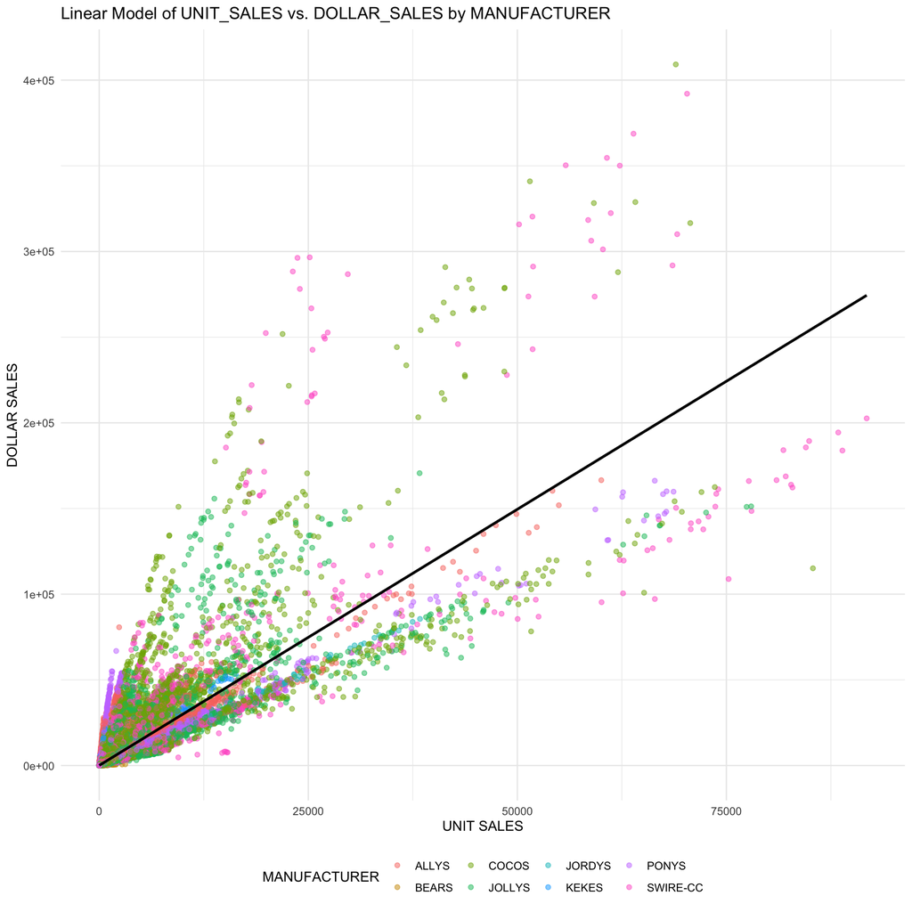

```r
# Create a scatter plot with the regression line, colored by MANUFACTURER
ggplot(df, aes(x = UNIT_SALES, y = DOLLAR_SALES, color = MANUFACTURER)) +
  geom_point(alpha = 0.5) +  # Adjust alpha to avoid overplotting, if necessary
  geom_smooth(method = "lm", color = "black", se = FALSE) +  # Add linear regression line without confidence band for clarity
  labs(title = "Linear Model of UNIT_SALES vs. DOLLAR_SALES by MANUFACTURER",
       x = "UNIT SALES",
       y = "DOLLAR SALES") +
  theme_minimal() +
  theme(legend.position = "bottom")  # Adjust legend position if needed
```

```r
# create a table of total values by brand
brand_summary <- df %>%
  group_by(BRAND) %>%
  summarise(
    total_units_sold = sum(UNIT_SALES),
    total_revenue = sum(DOLLAR_SALES),
    avg_price = total_revenue / total_units_sold,
    total_days_sold = n() # Count the number of rows for each brand
  ) %>%
  arrange(desc(total_units_sold)) %>%  # Order by revenue in descending order
  mutate(rank = row_number())

summary(brand_summary)
```

```
##     BRAND           total_units_sold   total_revenue         avg_price
##  Length:288         Min.   :       1   Min.   :        1   Min.   : 0.5315
##  Class :character   1st Qu.:    2310   1st Qu.:     7563   1st Qu.: 2.0861
##  Mode  :character   Median :   94691   Median :   266075   Median : 3.0291
##                     Mean   : 1473003   Mean   :  4989427   Mean   : 3.2661
##                     3rd Qu.:  651385   3rd Qu.:  2161764   3rd Qu.: 3.7252
##                     Max.   :40414038   Max.   :159387186   Max.   :42.9378
##  total_days_sold         rank
##  Min.   :     1.0   Min.   :  1.00
##  1st Qu.:   121.8   1st Qu.: 72.75
##  Median :  1988.0   Median :144.50
##  Mean   :  8493.5   Mean   :144.50
##  3rd Qu.:  8075.8   3rd Qu.:216.25
##  Max.   :124603.0   Max.   :288.00
```

```r
print(brand_summary[brand_summary$BRAND == "PEPPY", ])
```

```
## # A tibble: 1 × 6
##   BRAND total_units_sold total_revenue avg_price total_days_sold  rank
##   <chr>            <dbl>         <dbl>     <dbl>           <int> <int>
## 1 PEPPY        24118678.     89515431.      3.71           39613     3
```

> Peppy is a hugly popular brand coming in at 3rd in total revenue and 3rd in total units sold

## Take a look at your brand..

```r
# Filter the dataframe for only 'PEPPY'
filtered_df <- df %>%
  filter(BRAND == "PEPPY")


summary(filtered_df)
```

```
##   MARKET_KEY            DATE           CALORIC_SEGMENT   CATEGORY
##  Length:39613       Length:39613       Min.   :1       Length:39613
##  Class :character   Class :character   1st Qu.:1       Class :character
##  Mode  :character   Mode  :character   Median :1       Mode  :character
##                                        Mean   :1
##                                        3rd Qu.:1
##                                        Max.   :1
##    UNIT_SALES        DOLLAR_SALES      MANUFACTURER          BRAND
##  Min.   :    0.17   Min.   :     0.2   Length:39613       Length:39613
##  1st Qu.:   56.00   1st Qu.:   190.7   Class :character   Class :character
##  Median :  154.00   Median :   588.6   Mode  :character   Mode  :character
##  Mean   :  608.86   Mean   :  2259.7
##  3rd Qu.:  481.00   3rd Qu.:  1824.8
##  Max.   :91778.00   Max.   :392062.7
##    PACKAGE              ITEM              REGION              MONTH
##  Length:39613       Length:39613       Length:39613       Min.   : 1.000
##  Class :character   Class :character   Class :character   1st Qu.: 3.000
##  Mode  :character   Mode  :character   Mode  :character   Median : 6.000
##                                                           Mean   : 6.306
##                                                           3rd Qu.: 9.000
##                                                           Max.   :12.000
##     SEASON
##  Length:39613
##  Class :character
##  Mode  :character
##
##
##
```

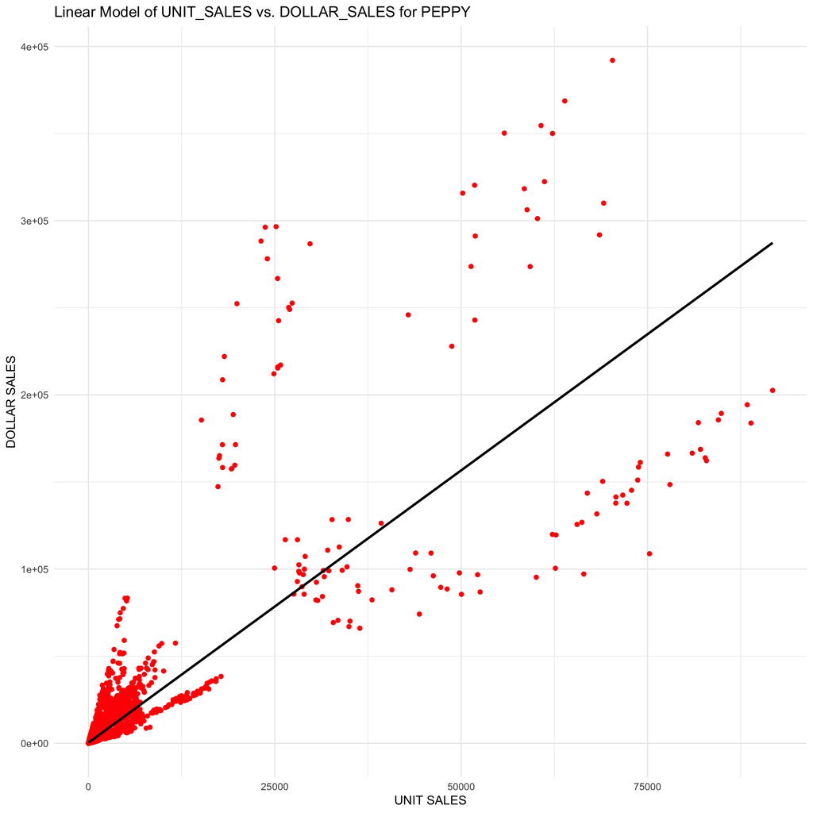

```r
# Create the plot
ggplot(filtered_df, aes(x = UNIT_SALES, y = DOLLAR_SALES)) +
  geom_point(color = "red", alpha = 1) +  # Bright red points with full opacity
  geom_smooth(method = "lm", color = "black", se = FALSE) +  # Add linear regression line without confidence band
  labs(title = "Linear Model of UNIT_SALES vs. DOLLAR_SALES for PEPPY",
       x = "UNIT SALES",
       y = "DOLLAR SALES") +
  theme_minimal() +
  theme(legend.position = "none")
```

>PEPPY only has multiple sizes of their one drink “GENTLE DRINK RED PEPPER COLA”

```r
# Check Tenure of all items
filtered_df %>%
  mutate(DATE = as.Date(DATE)) %>%
    group_by(ITEM) %>%
  summarize(Date_Difference = difftime(max(DATE), min(DATE), units = "weeks"),
            Total_Unit_Sales = sum(UNIT_SALES)) %>%
  arrange(Date_Difference)
```

```
## # A tibble: 38 × 3
##    ITEM                                         Date_Difference Total_Unit_Sales
##    <chr>                                        <drtn>                     <dbl>
##  1 PEPPY GENTLE DRINK RED  PEPPER COLA CUP 8 L…   0 weeks                      1
##  2 PEPPY GENTLE DRINK RED  PEPPER COLA JUG 12.…   0 weeks                      1
##  3 PEPPY GENTLE DRINK RED  PEPPER COLA CUP 12 …  71 weeks                      2
##  4 PEPPY GENTLE DRINK RED  PEPPER COLA JUG 16 …  74 weeks                     18
##  5 PEPPY GENTLE DRINK RED  PEPPER COLA JUG 12 …  83 weeks                    326
##  6 PEPPY GENTLE DRINK RED  PEPPER COLA JUG 13.… 104 weeks                  17234
##  7 PEPPY GENTLE DRINK RED  PEPPER COLA JUG 67.… 113 weeks                   7818
##  8 PEPPY GENTLE DRINK RED  PEPPER COLA CUP 7.5… 120 weeks                  20545
##  9 PEPPY GENTLE DRINK RED  PEPPER COLA CUP 12 … 128 weeks                    524
## 10 PEPPY GENTLE DRINK RED  PEPPER COLA JUG 12 … 134 weeks                    104
## # ℹ 28 more rows
```

> Peppy only has 2 products that could be considered innovation products, but they each were only sold once and each only sold 1 unit.

```r
#check for Pink woodsy flavor sales
sales_by_pink_woodsy <- df %>%
  filter(str_detect(ITEM, "PINK") & str_detect(ITEM, "WOODSY"))
```

> there are no current sales around pink woodsy flavored data.

```r
#check for packaging
df %>%
  filter(CATEGORY == "SSD",
         CALORIC_SEGMENT == 1,
         str_detect(PACKAGE, "JUG") & str_detect(PACKAGE, "\\.5L") & str_detect(PACKAGE, "MULTI")) %>%
  mutate(PACKAGE = as.factor(PACKAGE))
```

```
##    MARKET_KEY       DATE CALORIC_SEGMENT CATEGORY UNIT_SALES DOLLAR_SALES
## 1         132 2023-01-28               1      SSD          1         1.50
## 2           6 2023-07-08               1      SSD          1         1.50
## 3        1172 2023-02-04               1      SSD          1         1.50
## 4        1172 2022-02-12               1      SSD          1         1.25
## 5        1135 2021-04-10               1      SSD          1         1.00
## 6         817 2023-02-18               1      SSD          1         1.50
## 7        1172 2022-08-27               1      SSD          1         1.25
## 8         399 2023-01-28               1      SSD          2         3.00
## 9         535 2021-10-16               1      SSD          2         2.00
## 10        216 2022-04-09               1      SSD          1         1.25
##    MANUFACTURER         BRAND        PACKAGE
## 1        JOLLYS HILL MOISTURE 1.5L MULTI JUG
## 2        JOLLYS          PAPI 1.5L MULTI JUG
## 3        JOLLYS HILL MOISTURE 1.5L MULTI JUG
```

[output cut: 18 more lines]

## Sales by Week of the year

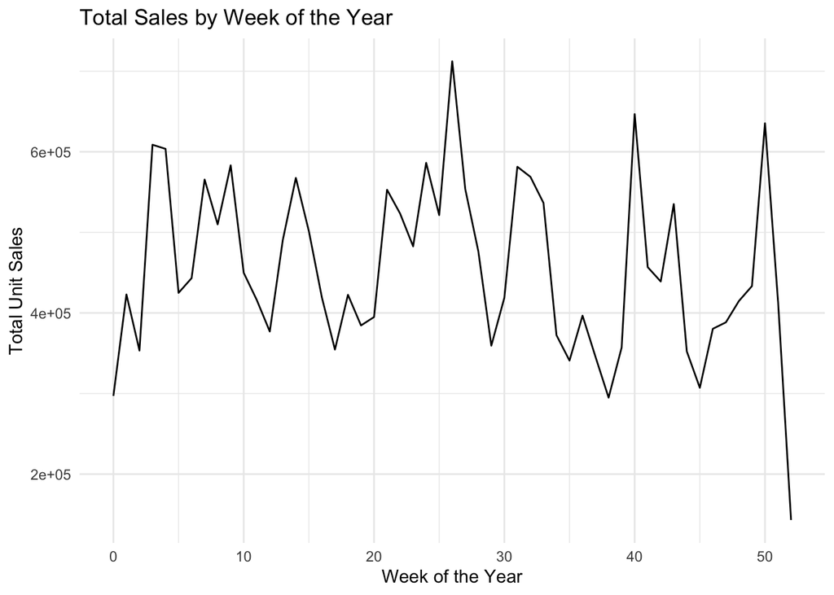

```r
filtered_df %>%
  mutate(DATE = as.Date(DATE)) %>%
  mutate(WEEK = as.integer(format(DATE, "%U"))) %>%
  group_by(WEEK) %>%
  summarise(total_sales = sum(UNIT_SALES)) %>%
  ggplot(aes(x = WEEK, y = total_sales)) +
  geom_line(color = "black") +  # Blue line connecting points
  labs(title = "Total Sales by Week of the Year",
       x = "Week of the Year",
       y = "Total Unit Sales") +
  theme_minimal()
```

```r
#find the best 13 weeks
library(zoo)
```

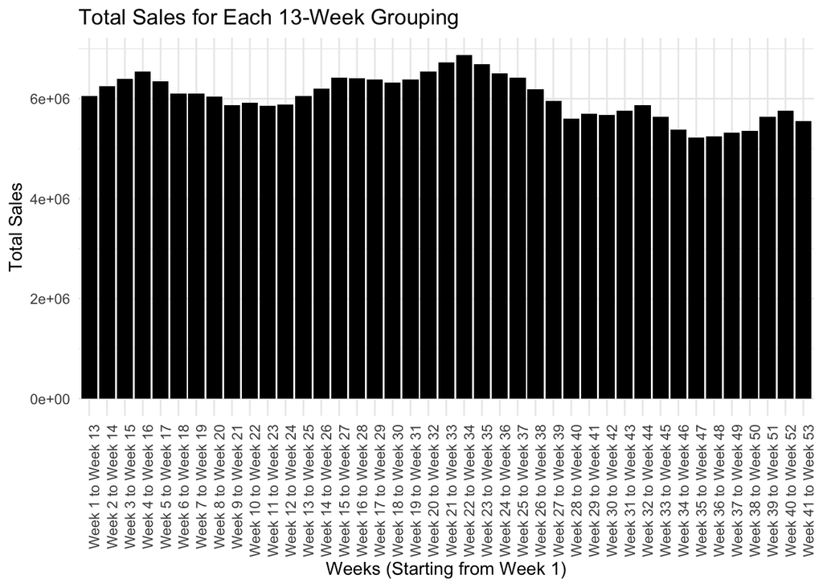

```r
# Calculate total sales for each group of 13 consecutive weeks
sales_by_group <- filtered_df %>%
  mutate(DATE = as.Date(DATE)) %>%
  mutate(WEEK = as.integer(format(DATE, "%U"))) %>%
  group_by(WEEK) %>%
  summarise(total_sales = sum(UNIT_SALES)) %>%
  mutate(sales_in_group = rollsum(total_sales, 13, align = "left", fill = NA)) %>%
  mutate(week_label = paste0("Week ", WEEK + 1, " to Week ", WEEK + 13)) %>%
  arrange(WEEK) %>%  # Order by WEEK
  filter(!is.na(sales_in_group))  # Remove rows with sales_in_group = NA

# Plot the bar chart
sales_by_group$week_label <- factor(sales_by_group$week_label, levels = sales_by_group$week_label[order(sales_by_group$WEEK)])
ggplot(sales_by_group, aes(x = factor(week_label), y = sales_in_group)) +
  geom_bar(stat = "identity", fill = "black") +
  labs(title = "Total Sales for Each 13-Week Grouping",
       x = "Weeks (Starting from Week 1)",
       y = "Total Sales") +
  theme_minimal() +
  theme(axis.text.x = element_text(angle = 90, hjust = 1))
```

## Made a new smaller “innovation” data fram

```r
innovation <- df %>%
  filter(CATEGORY == "SSD",
         CALORIC_SEGMENT == 1,
         str_detect(ITEM, "PINK") | str_detect(ITEM, "WOODSY"))

print(unique(innovation$ITEM))
```

```
##  [1] "FANTASMIC GENTLE DRINK PINK  CUP 12 LIQUID SMALL X12"
##  [2] "KOOL! FLUFFY GENTLE DRINK KIWANO  PINK  CUP 12 LIQUID SMALL"
##  [3] "MOONLIT GENTLE DRINK PINK  ADE  CUP 7.5 LIQUID SMALL X6"
##  [4] "FANTASMIC GENTLE DRINK PINK  JUG 12 LIQUID SMALL"
##  [5] "FANTASMIC GENTLE DRINK PINK  JUG 20 LIQUID SMALL"
##  [6] "MOONLIT GENTLE DRINK PINK  ADE  JUG 20 LIQUID SMALL"
##  [7] "MOONLIT GENTLE DRINK PINK  ADE  CUP 12 LIQUID SMALL X12"
##  [8] "SMASH GENTLE DRINK PINK  JUG 12 LIQUID SMALL X4"
##  [9] "MOONLIT GENTLE DRINK PINK  JUG 20 LIQUID SMALL"
## [10] "RAINING COASTAL BLAST GENTLE DRINK WOODSY  DURIAN  CUP 7.5 LIQUID SMALL X10"
## [11] "ZIZZLES GENTLE DRINK PINK  JUG 67.6 LIQUID SMALL"
## [12] "RAINING KICK DARK ENERGY DRINK PINK  SUPER-JUICE  CUP 16 LIQUID SMALL"
## [13] "SMASH GENTLE DRINK PINK  CUP 12 LIQUID SMALL X12"
## [14] "SMASH GENTLE DRINK PINK  JUG 67.6 LIQUID SMALL"
## [15] "FANTASMIC GENTLE DRINK PINK  JUG 67.6 LIQUID SMALL"
```

[output cut: 45 more lines]

```r
#there are 60 items with SSD, Regular, and PINT OR WOODSY, but none of them are from PEPPY.

#Add a month Date factor
library(dplyr)
library(lubridate)

innovation <- innovation %>%
  mutate(
    MONTH = month(ymd(DATE)),  # Extract month using lubridate's ymd function
    MONTH = as.factor(MONTH)   # Convert the extracted month into a factor
  )

str(innovation)
```

```
## 'data.frame':    31460 obs. of  13 variables:
##  $ MARKET_KEY     : chr  "187" "583" "61" "32" ...
##  $ DATE           : chr  "2022-09-10" "2022-09-17" "2022-12-24" "2021-03-20" ...
##  $ CALORIC_SEGMENT: num  1 1 1 1 1 1 1 1 1 1 ...
##  $ CATEGORY       : chr  "SSD" "SSD" "SSD" "SSD" ...
##  $ UNIT_SALES     : num  65 6 5 31 119 20 12 1 5 13 ...
##  $ DOLLAR_SALES   : num  348.7 15.9 20.9 40 274.6 ...
##  $ MANUFACTURER   : chr  "COCOS" "COCOS" "SWIRE-CC" "COCOS" ...
##  $ BRAND          : chr  "FANTASMIC" "FLUFFY'S LIMITED EDITION KOOL!" "MOONLIT" "MEXICAN FANTASMIC" ...
##  $ PACKAGE        : chr  "12SMALL 12ONE CUP" "12SMALL MLT BUMPY CUP" "7.5SMALL 6ONE CUP" "12SMALL MLT PLASTICS JUG" ...
##  $ ITEM           : chr  "FANTASMIC GENTLE DRINK PINK  CUP 12 LIQUID SMALL X12" "KOOL! FLUFFY GENTLE DRINK KIWANO  PINK  CUP 12 LIQUID SMALL" "MOONLIT GENTLE DRINK PINK  ADE  CUP 7.5 LIQUID SMALL X6" "FANTASMIC GENTLE DRINK PINK  JUG 12 LIQUID SMALL" ...
##  $ REGION         : chr  "NORTHERN" "NOCAL" "NORTHERN" "NORTHERN" ...
##  $ MONTH          : Factor w/ 12 levels "1","2","3","4",..: 9 9 12 3 8 8 8 1 4 4 ...
##  $ SEASON         : chr  "FALL" "FALL" "WINTER" "SPRING" ...
```

```r
# Assuming 'innovation' is your data frame
model <- lm(DOLLAR_SALES ~ UNIT_SALES + CALORIC_SEGMENT + PACKAGE + SEASON + REGION, data = innovation)
summary(model)
```

```
##
## Call:
## lm(formula = DOLLAR_SALES ~ UNIT_SALES + CALORIC_SEGMENT + PACKAGE +
##     SEASON + REGION, data = innovation)
##
## Residuals:
##     Min      1Q  Median      3Q     Max
## -9653.6   -92.1    14.0    66.4 24621.9
##
## Coefficients: (1 not defined because of singularities)
##                                     Estimate Std. Error t value Pr(>|t|)
## (Intercept)                        5.089e+01  1.625e+01   3.132 0.001735 **
## UNIT_SALES                         2.542e+00  9.985e-03 254.532  < 2e-16 ***
## CALORIC_SEGMENT                           NA         NA      NA       NA
## PACKAGE12SMALL 12ONE CUP           1.249e+02  1.556e+01   8.029 1.02e-15 ***
## PACKAGE12SMALL 24ONE CUP           2.942e+02  1.405e+02   2.093 0.036342 *
## PACKAGE12SMALL 24ONE PLASTICS JUG -5.699e+01  2.421e+02  -0.235 0.813940
## PACKAGE12SMALL 36ONE CUP           1.396e+03  5.216e+01  26.768  < 2e-16 ***
## PACKAGE12SMALL 4ONE PLASTICS JUG  -9.412e+01  2.591e+01  -3.633 0.000280 ***
## PACKAGE12SMALL 6ONE CUP           -1.556e+02  2.574e+01  -6.044 1.52e-09 ***
## PACKAGE12SMALL MLT BUMPY CUP      -1.124e+02  2.146e+01  -5.239 1.62e-07 ***
## PACKAGE12SMALL MLT PLASTICS JUG   -1.041e+02  1.963e+01  -5.305 1.14e-07 ***
## PACKAGE16SMALL MLT SHADYES JUG    -5.426e+01  4.187e+02  -0.130 0.896897
## PACKAGE16SMALL MULTI CUP          -2.802e+02  7.710e+01  -3.634 0.000279 ***
## PACKAGE1L MULTI JUG               -1.647e+02  7.232e+01  -2.277 0.022792 *
## PACKAGE20SMALL MULTI JUG          -1.518e+02  1.565e+01  -9.698  < 2e-16 ***
## PACKAGE24SMALL MLT SHADYES JUG    -1.060e+02  5.313e+01  -1.994 0.046151 *
## PACKAGE2L MULTI JUG               -1.676e+02  1.574e+01 -10.643  < 2e-16 ***
## PACKAGE7.5SMALL 10ONE CUP         -4.654e+01  3.437e+01  -1.354 0.175692
## PACKAGE7.5SMALL 6ONE CUP          -6.977e+01  1.832e+01  -3.808 0.000140 ***
## PACKAGEALL OTHER ONES             -6.006e+01  5.974e+01  -1.005 0.314734
## SEASONSPRING                       1.773e+00  7.034e+00   0.252 0.800953
## SEASONSUMMER                       4.245e+01  6.569e+00   6.462 1.05e-10 ***
## SEASONWINTER                      -6.942e+00  7.104e+00  -0.977 0.328497
## REGIONCALI_NEVADA                  1.121e+01  1.334e+01   0.840 0.400718
## REGIONCOLORADO                     3.355e+01  8.397e+00   3.996 6.46e-05 ***
## REGIONDESERT_SW                    9.157e+00  9.602e+00   0.954 0.340272
## REGIONKANSAS                       7.939e+01  1.551e+01   5.119 3.10e-07 ***
## REGIONMOUNTAIN                     6.719e+01  1.079e+01   6.229 4.75e-10 ***
## REGIONNEWMEXICO                    2.700e+01  1.140e+01   2.368 0.017875 *
## REGIONNOCAL                        8.286e+00  1.174e+01   0.706 0.480380
## REGIONNORTHERN                     3.742e+01  7.222e+00   5.182 2.21e-07 ***
## REGIONPRAIRIE                      5.414e+01  1.468e+01   3.689 0.000226 ***
## REGIONSOCAL                       -1.091e+01  9.029e+00  -1.209 0.226720
## ---
## Signif. codes:  0 '***' 0.001 '**' 0.01 '*' 0.05 '.' 0.1 ' ' 1
##
## Residual standard error: 418.4 on 31428 degrees of freedom
## Multiple R-squared:  0.7225, Adjusted R-squared:  0.7222
## F-statistic:  2639 on 31 and 31428 DF,  p-value: < 2.2e-16
```

### More exploration

```r
library(dplyr)

small_group <- df %>%
  filter(UNIT_SALES < 76000, DOLLAR_SALES < 500000)

skim(small_group)
```

Data summary

| Name | small_group |
| --- | --- |
| Number of rows | 2446128 |
| Number of columns | 13 |
| _______________________ |  |
| Column type frequency: |  |
| character | 9 |
| numeric | 4 |
| ________________________ |  |
| Group variables | None |

**Variable type: character**

| skim_variable | n_missing | complete_rate | min | max | empty | n_unique | whitespace |
| --- | --- | --- | --- | --- | --- | --- | --- |
| MARKET_KEY | 0 | 1 | 1 | 4 | 0 | 200 | 0 |
| DATE | 0 | 1 | 10 | 10 | 0 | 152 | 0 |
| CATEGORY | 0 | 1 | 3 | 18 | 0 | 5 | 0 |
| MANUFACTURER | 0 | 1 | 5 | 8 | 0 | 8 | 0 |
| BRAND | 0 | 1 | 4 | 56 | 0 | 288 | 0 |
| PACKAGE | 0 | 1 | 11 | 26 | 0 | 95 | 0 |
| ITEM | 0 | 1 | 26 | 142 | 0 | 2999 | 0 |
| REGION | 0 | 1 | 5 | 11 | 0 | 11 | 0 |
| SEASON | 0 | 1 | 4 | 6 | 0 | 4 | 0 |

**Variable type: numeric**

| skim_variable | n_missing | complete_rate | mean | sd | p0 | p25 | p50 | p75 | p100 | hist |
| --- | --- | --- | --- | --- | --- | --- | --- | --- | --- | --- |
| CALORIC_SEGMENT | 0 | 1 | 0.50 | 0.50 | 0.00 | 0.00 | 1.00 | 1.00 | 1.0 | ▇▁▁▁▇ |
| UNIT_SALES | 0 | 1 | 172.92 | 808.77 | 0.04 | 11.00 | 40.00 | 126.00 | 75266.0 | ▇▁▁▁▁ |
| DOLLAR_SALES | 0 | 1 | 586.41 | 2915.60 | 0.01 | 36.47 | 135.06 | 427.39 | 409159.3 | ▇▁▁▁▁ |
| MONTH | 0 | 1 | 6.28 | 3.43 | 1.00 | 3.00 | 6.00 | 9.00 | 12.0 | ▇▆▆▅▇ |

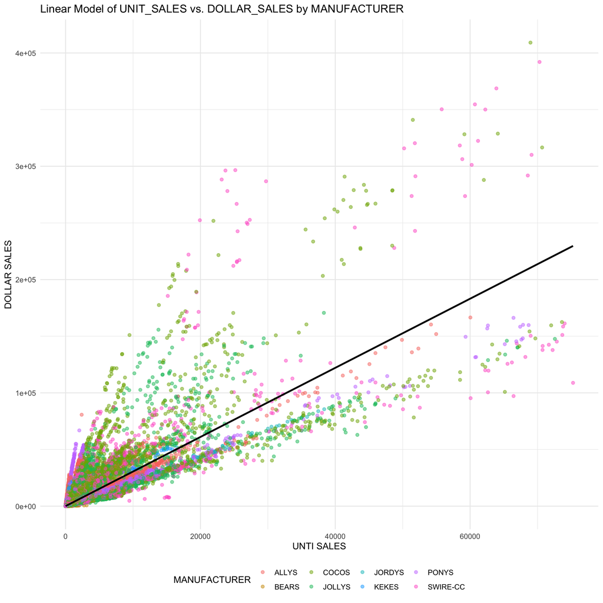

```r
# Create a scatter plot with the regression line, colored by MANUFACTURER
ggplot(small_group, aes(x = UNIT_SALES, y = DOLLAR_SALES, color = MANUFACTURER)) +
  geom_point(alpha = 0.5) +  # Adjust alpha to avoid overplotting, if necessary
  geom_smooth(method = "lm", color = "black", se = FALSE) +  # Add linear regression line without confidence band for clarity
  labs(title = "Linear Model of UNIT_SALES vs. DOLLAR_SALES by MANUFACTURER",
       x = "UNTI SALES",
       y = "DOLLAR SALES") +
  theme_minimal() +
  theme(legend.position = "bottom")  # Adjust legend position if needed
```

> This is where Peppy lives, as they are one of the highest in unit sales and revenue it is grabbing essentially everything.

#Make the small pink woodsy

```r
pinkwoodsy_small <- df[grep("pink|woodsy", df$ITEM, ignore.case = TRUE), ]
```

```r
skim(pinkwoodsy_small)
```

Data summary

| Name | pinkwoodsy_small |
| --- | --- |
| Number of rows | 136043 |
| Number of columns | 13 |
| _______________________ |  |
| Column type frequency: |  |
| character | 9 |
| numeric | 4 |
| ________________________ |  |
| Group variables | None |

**Variable type: character**

| skim_variable | n_missing | complete_rate | min | max | empty | n_unique | whitespace |
| --- | --- | --- | --- | --- | --- | --- | --- |
| MARKET_KEY | 0 | 1 | 1 | 4 | 0 | 200 | 0 |
| DATE | 0 | 1 | 10 | 10 | 0 | 152 | 0 |
| CATEGORY | 0 | 1 | 3 | 18 | 0 | 4 | 0 |
| MANUFACTURER | 0 | 1 | 5 | 8 | 0 | 7 | 0 |
| BRAND | 0 | 1 | 5 | 45 | 0 | 55 | 0 |
| PACKAGE | 0 | 1 | 11 | 26 | 0 | 38 | 0 |
| ITEM | 0 | 1 | 45 | 112 | 0 | 165 | 0 |
| REGION | 0 | 1 | 5 | 11 | 0 | 11 | 0 |
| SEASON | 0 | 1 | 4 | 6 | 0 | 4 | 0 |

**Variable type: numeric**

| skim_variable | n_missing | complete_rate | mean | sd | p0 | p25 | p50 | p75 | p100 | hist |
| --- | --- | --- | --- | --- | --- | --- | --- | --- | --- | --- |
| CALORIC_SEGMENT | 0 | 1 | 0.57 | 0.50 | 0.00 | 0.0 | 1.00 | 1.0 | 1.00 | ▆▁▁▁▇ |
| UNIT_SALES | 0 | 1 | 105.66 | 298.79 | 0.04 | 9.0 | 31.00 | 97.0 | 17037.00 | ▇▁▁▁▁ |
| DOLLAR_SALES | 0 | 1 | 263.76 | 799.55 | 0.01 | 27.3 | 88.41 | 243.8 | 46442.23 | ▇▁▁▁▁ |
| MONTH | 0 | 1 | 6.37 | 3.37 | 1.00 | 4.0 | 6.00 | 9.0 | 12.00 | ▇▆▆▅▇ |

```r
# Assuming 'innovation' is your data frame
model <- lm(DOLLAR_SALES ~ UNIT_SALES + CALORIC_SEGMENT + PACKAGE + CATEGORY + SEASON + REGION, data = pinkwoodsy_small)
summary(model)
```

```
##
## Call:
## lm(formula = DOLLAR_SALES ~ UNIT_SALES + CALORIC_SEGMENT + PACKAGE +
##     CATEGORY + SEASON + REGION, data = pinkwoodsy_small)
##
## Residuals:
##     Min      1Q  Median      3Q     Max
## -8326.5   -50.0     3.7    55.5 25354.4
##
## Coefficients:
##                                     Estimate Std. Error t value Pr(>|t|)
## (Intercept)                        4.624e+02  1.199e+01  38.569  < 2e-16 ***
## UNIT_SALES                         2.450e+00  3.054e-03 802.428  < 2e-16 ***
## CALORIC_SEGMENT                   -6.249e+01  2.535e+00 -24.647  < 2e-16 ***
## PACKAGE.5L 6ONE JUG               -1.631e+02  5.820e+00 -28.024  < 2e-16 ***
## PACKAGE.5L MULTI JUG              -3.273e+02  1.146e+01 -28.561  < 2e-16 ***
## PACKAGE12SMALL 12ONE CUP          -8.108e+01  6.486e+00 -12.502  < 2e-16 ***
## PACKAGE12SMALL 24ONE CUP          -3.706e+02  1.580e+01 -23.452  < 2e-16 ***
## PACKAGE12SMALL 24ONE PLASTICS JUG -2.835e+02  1.664e+02  -1.703   0.0885 .
## PACKAGE12SMALL 36ONE CUP           1.222e+03  3.493e+01  34.968  < 2e-16 ***
## PACKAGE12SMALL 4ONE PLASTICS JUG  -2.833e+02  1.567e+01 -18.083  < 2e-16 ***
## PACKAGE12SMALL 6ONE CUP           -2.675e+02  1.208e+01 -22.139  < 2e-16 ***
## PACKAGE12SMALL 8ONE BUMPY CUP     -4.375e+02  2.881e+02  -1.518   0.1289
## PACKAGE12SMALL 8ONE CUP           -2.609e+02  1.212e+01 -21.518  < 2e-16 ***
## PACKAGE12SMALL MLT BUMPY CUP      -3.360e+02  9.705e+00 -34.626  < 2e-16 ***
## PACKAGE12SMALL MLT PLASTICS JUG   -3.006e+02  1.049e+01 -28.663  < 2e-16 ***
## PACKAGE12SMALL MULTI CUP          -1.950e+02  1.270e+01 -15.350  < 2e-16 ***
## PACKAGE15SMALL MLT                -5.264e+02  1.542e+01 -34.143  < 2e-16 ***
## PACKAGE16SMALL 12ONE CUP          -4.707e+02  2.241e+01 -21.007  < 2e-16 ***
## PACKAGE16SMALL 24ONE CUP          -4.416e+02  1.922e+01 -22.978  < 2e-16 ***
## PACKAGE16SMALL MLT SHADYES JUG    -2.771e+02  2.881e+02  -0.962   0.3362
## PACKAGE16SMALL MULTI CUP          -4.584e+02  1.186e+01 -38.633  < 2e-16 ***
## PACKAGE18SMALL 6ONE               -1.642e+02  9.041e+00 -18.166  < 2e-16 ***
## PACKAGE18SMALL MULTI JUG          -2.256e+02  5.655e+00 -39.900  < 2e-16 ***
## PACKAGE1L MULTI JUG               -2.266e+02  1.172e+01 -19.340  < 2e-16 ***
## PACKAGE20SMALL 12ONE JUG          -1.370e+02  2.241e+01  -6.112 9.88e-10 ***
## PACKAGE20SMALL MULTI JUG          -3.505e+02  5.214e+00 -67.216  < 2e-16 ***
## PACKAGE24 - 25SMALL MULTI JUG     -2.753e+02  6.331e+00 -43.485  < 2e-16 ***
## PACKAGE24SMALL MLT SHADYES JUG    -3.066e+02  3.546e+01  -8.646  < 2e-16 ***
## PACKAGE24SMALL MULTI CUP          -4.019e+02  1.796e+01 -22.377  < 2e-16 ***
```

[output cut: 18 more lines]

```
## REGIONCOLORADO                     1.785e+01  2.791e+00   6.394 1.62e-10 ***
## REGIONDESERT_SW                    2.866e+00  3.315e+00   0.865   0.3873
## REGIONKANSAS                       1.159e+02  5.992e+00  19.343  < 2e-16 ***
## REGIONMOUNTAIN                     1.330e+01  3.104e+00   4.286 1.82e-05 ***
## REGIONNEWMEXICO                    1.652e+01  4.059e+00   4.069 4.72e-05 ***
## REGIONNOCAL                        7.681e+00  4.255e+00   1.805   0.0710 .
## REGIONNORTHERN                     1.120e+01  2.287e+00   4.895 9.82e-07 ***
## REGIONPRAIRIE                      2.146e+01  4.975e+00   4.313 1.61e-05 ***
## REGIONSOCAL                       -6.204e+00  3.245e+00  -1.912   0.0559 .
## ---
## Signif. codes:  0 '***' 0.001 '**' 0.01 '*' 0.05 '.' 0.1 ' ' 1
##
## Residual standard error: 288 on 135987 degrees of freedom
## Multiple R-squared:  0.8703, Adjusted R-squared:  0.8703
## F-statistic: 1.659e+04 on 55 and 135987 DF,  p-value: < 2.2e-16
```

## Cleaning

> Rework pinkwoodsy for more features

```r
pinkwoodsy_small <- df %>%
  filter(CATEGORY == "SSD",
         CALORIC_SEGMENT == 1, # Specify each pattern separately
         REGION %in% c("NEWMEXICO", "ARIZONA", "DESERT_SW"))

pinkwoodsy_small <- pinkwoodsy_small %>%
  mutate(
    PACKAGE2 = str_extract(ITEM, "(CUP|JUG).*"),  # Extracts the part from CUP or JUG to the end.
    ITEM = str_replace(ITEM, "(CUP|JUG).*", "")  # Replaces the CUP/JUG and everything after it with empty string in ITEM.
  )
```

```r
pinkwoodsy_small <- pinkwoodsy_small %>%
  mutate(
    TEMP = str_extract(ITEM, "\\d+\\.?\\d*.*"), # Extracts the part from the first number to the end.
    PACKAGE2 = if_else(is.na(PACKAGE2), TEMP, paste(PACKAGE2, TEMP)), # Combines existing PACKAGE2 with new extraction if needed.
    ITEM = str_replace(ITEM, "\\d+\\.?\\d*.*", ""), # Removes the numeric part and everything after it from ITEM.
    TEMP = NULL  # Removes the temporary column.
  )
```

```r
na_rows <- pinkwoodsy_small %>%
  filter(is.na(PACKAGE2))
#na_rows
#the above steps excised all packaging out of ITEM column
```

```r
pinkwoodsy_small <- pinkwoodsy_small %>%
  mutate(
    GENTLE_DRINK = if_else(str_detect(ITEM, "GENTLE DRINK"), 1, 0), # Assigns 1 if "GENTLE DRINK" exists, otherwise 0.
    ITEM = str_replace(ITEM, "GENTLE DRINK", "") # Removes "GENTLE DRINK" from ITEM.
  )
```

```r
pinkwoodsy_small <- pinkwoodsy_small %>%
  mutate(
    ENERGY_DRINK = if_else(str_detect(ITEM, "ENERGY DRINK"), 1, 0), # Assigns 1 if "ENERGY DRINK" exists, otherwise 0.
    ITEM = str_replace(ITEM, "ENERGY DRINK", "") # Removes "ENERGY DRINK" from ITEM.
  )
```

```r
library(stringr)
# Define the pattern as a regular expression
pattern <- "ZERO CALORIES|ZERO CALORIE|ZERO SUGAR|SUGAR FREE|NO CALORIES"

pinkwoodsy_small <- pinkwoodsy_small %>%
  mutate(
    CALORIC_SEGMENT_TEXT = str_extract(ITEM, pattern), # Extracts matching text based on the pattern.
    ITEM = str_replace_all(ITEM, pattern, "") # Removes extracted text from ITEM.
  )
```

```r
pinkwoodsy_small <- pinkwoodsy_small %>%
  mutate(
    CALORIC_SEGMENT_TEXT = if_else(str_detect(ITEM, "\\bDIET\\b"),
                                   if_else(is.na(CALORIC_SEGMENT_TEXT), "DIET", paste(CALORIC_SEGMENT_TEXT, "DIET", sep=", ")),
                                   CALORIC_SEGMENT_TEXT)
  )
```

```r
# Function to remove the second instance of any repeating word
remove_second_instance <- function(item) {
  words <- unlist(str_split(item, "\\s+")) # Split item into words
  unique_words <- unique(words) # Get unique words to check for repeats
  for (word in unique_words) {
    word_indices <- which(words == word) # Find all indices of the current word
    if (length(word_indices) > 1) { # If there is more than one occurrence
      words[word_indices[2]] <- "" # Remove the second occurrence
    }
  }
  return(paste(words, collapse = " ")) # Reconstruct sentence without the second instance
}

# Apply the function to the 'ITEM' column
pinkwoodsy_small <- pinkwoodsy_small %>%
  mutate(ITEM = sapply(ITEM, remove_second_instance))


# Remove specific columns
pinkwoodsy_small <- select(pinkwoodsy_small, -PACKAGE2, -GENTLE_DRINK, -ENERGY_DRINK, -CALORIC_SEGMENT_TEXT)
```

```r
head(pinkwoodsy_small)
```

```
##   MARKET_KEY       DATE CALORIC_SEGMENT CATEGORY UNIT_SALES DOLLAR_SALES
## 1        893 2022-02-26               1      SSD         37        60.74
## 2        794 2023-07-01               1      SSD        512      2854.85
## 3        882 2020-12-12               1      SSD         36        52.48
## 4        733 2023-04-22               1      SSD         38        86.28
## 5        585 2022-04-16               1      SSD        203       715.54
## 6        197 2021-07-10               1      SSD        329       380.65
##   MANUFACTURER         BRAND           PACKAGE                            ITEM
## 1     SWIRE-CC         SMASH      2L MULTI JUG                   SMASH PURPLE
## 2     SWIRE-CC   CUPADA ARID 12SMALL 12ONE CUP
## 3       JOLLYS HILL MOISTURE 16SMALL MULTI CUP                RAINING AVOCADO
## 4     SWIRE-CC      RESIDENT      2L MULTI JUG                RESIDENT GINGER
## 5        COCOS   ELF BUBBLES      .5L 6ONE JUG ELF BUBBLES SUPER-JUICE DURIAN
## 6        COCOS   ELF BUBBLES   1.25L MULTI JUG ELF BUBBLES SUPER-JUICE DURIAN
##      REGION MONTH SEASON
## 1   ARIZONA     2 WINTER
## 2   ARIZONA     7 SUMMER
## 3   ARIZONA    12 WINTER
## 4   ARIZONA     4 SPRING
## 5   ARIZONA     4 SPRING
## 6 DESERT_SW     7 SUMMER
```

```r
write.csv(pinkwoodsy_small, "pinkwoodsy_small.csv", row.names = FALSE)
```

# FINAL THOUGHTS

> Thorugh our analysis of a “Pink Woodsy” flavored launch, there was very little evidance that further modeling would create a reliable prediction. As the historical data is missing many accurate features we would like to see in order do explaine variation. A few of the features from this specific innovation product that are missing are: 1. Lack of compariabel flavors. Though there have been products in the past with Pink or Woodsy, there has never been any items with this combination. 2. Brand “Peppy” having no innovation product data. In our research of the brand we found they do not have any innovation data that would give us indications of how a new product would compete if launched. 3. Lack of deffinition of which regions or areas would be considered “South.” For this launch. With these crucical factors either being excluded from modeling or using best estimates on the “closest” items we do not believe moving forward with prediciton of this would be advised. With a product such as this any type of trials data or directions on which items would be most comparable would help assure accuracy.